# Quality Control miRNA arrays

Margalida Torrens Mas

8 de gener, 2025

# Introducción

Este trabajo tiene como objetivo explorar los cambios tempranos en los perfiles de expresión génica asociados con el desarrollo del cáncer colorrectal (CCR), que puedan ayudar en un futuro a identificar marcadores que optimicen los programas actuales de cribado. Concretamente, se pretende analizar la expresión génica diferencial entre distintos estadios de la enfermedad, representados por muestras control sin enfermedad, muestras de adenomas de alto grado con probabilidad de avanzar a neoplasia, y muestras de CCR. El RNA usado para este análisis proviene de vesículas extracelulares extraídas del aspirado intestinal obtenido durante colonoscopias.

# Control de calidad

En este apartado se analiza la calidad de los datos de partida, tanto antes como después del proceso de normalización. En este apartado se describe el control de calidad aplicado a los datos de miRNA.

## Lectura de datos

Se analizan los datos de los microarrays de miRNA de 3 muestras correspondientes a cáncer colorrectal, 3 correspondientes a adenomas de alto grado, y 3 controles.

```r
cel_files <- list.celfiles(params$raw_data_dir, full.names = T)
samples <- read.AnnotatedDataFrame(file.path(params$raw_data_dir, "misamples.csv"), header=TRUE, row.names=1, sep=";")

raw_data <- read.celfiles(cel_files, pkgname="pd.mirna.4.0", phenoData = samples)
```

```
## Reading in : C:/Users/Lidat/Desktop/Màster Bioinformàtica i Bioestadística UOC/TFM/midata/AR1mi.CEL
## Reading in : C:/Users/Lidat/Desktop/Màster Bioinformàtica i Bioestadística UOC/TFM/midata/AR2mi.CEL
## Reading in : C:/Users/Lidat/Desktop/Màster Bioinformàtica i Bioestadística UOC/TFM/midata/AR3mi.CEL
## Reading in : C:/Users/Lidat/Desktop/Màster Bioinformàtica i Bioestadística UOC/TFM/midata/CCR1mi.CEL
## Reading in : C:/Users/Lidat/Desktop/Màster Bioinformàtica i Bioestadística UOC/TFM/midata/CCR2mi.CEL
## Reading in : C:/Users/Lidat/Desktop/Màster Bioinformàtica i Bioestadística UOC/TFM/midata/CCR3.CEL
## Reading in : C:/Users/Lidat/Desktop/Màster Bioinformàtica i Bioestadística UOC/TFM/midata/CTRL1mi.CEL
## Reading in : C:/Users/Lidat/Desktop/Màster Bioinformàtica i Bioestadística UOC/TFM/midata/CTRL2.CEL
## Reading in : C:/Users/Lidat/Desktop/Màster Bioinformàtica i Bioestadística UOC/TFM/midata/CTRL3mi.CEL
```

```r
rownames(pData(raw_data)) <- samples@data$ShortName
colnames(raw_data) <- rownames(pData(raw_data))

head(raw_data) #check
```

```
## ExpressionFeatureSet (storageMode: lockedEnvironment)
## assayData: 6 features, 9 samples
##   element names: exprs
## protocolData
##   rowNames: Lesion1 Lesion2 ... Healthy3 (9 total)
##   varLabels: exprs dates
##   varMetadata: labelDescription channel
## phenoData
##   rowNames: Lesion1 Lesion2 ... Healthy3 (9 total)
##   varLabels: Group ShortName
##   varMetadata: labelDescription channel
## featureData: none
## experimentData: use 'experimentData(object)'
## Annotation: pd.mirna.4.0
```

## Visualización de la calidad

A continuación, se analiza de manera visual la distribución de los valores de expresión para detectar posibles fuentes de error, previamente a la normalización de los datos.

Se visualiza primero la densidad de los valores de intensidad de señal de los datos crudos mediante histograma y se compara la distribución entre los microarrays con un boxplot. Después, se realiza un análisis de calidad de cada microarray con `arrayQualityMetrics`. Se muestra directamente la tabla resumen con los outliers identificados. Las columnas llamadas 1, 2, 3, indican los distintos métodos para la detección de outliers. El método 1 corresponde a distancia entre arrays; el método 2, a boxplots; y el método 3 a los MA plots. Se marcan los outliers con ‘x’.

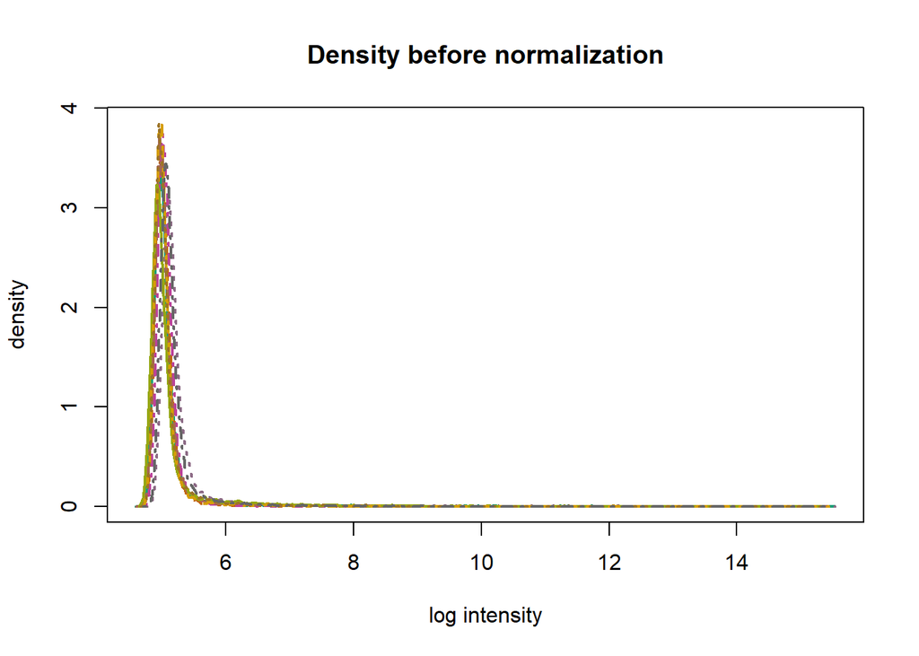

```r
hist(raw_data,lwd=2,xlab='log intensity', which='pm', main="Density before normalization")
```

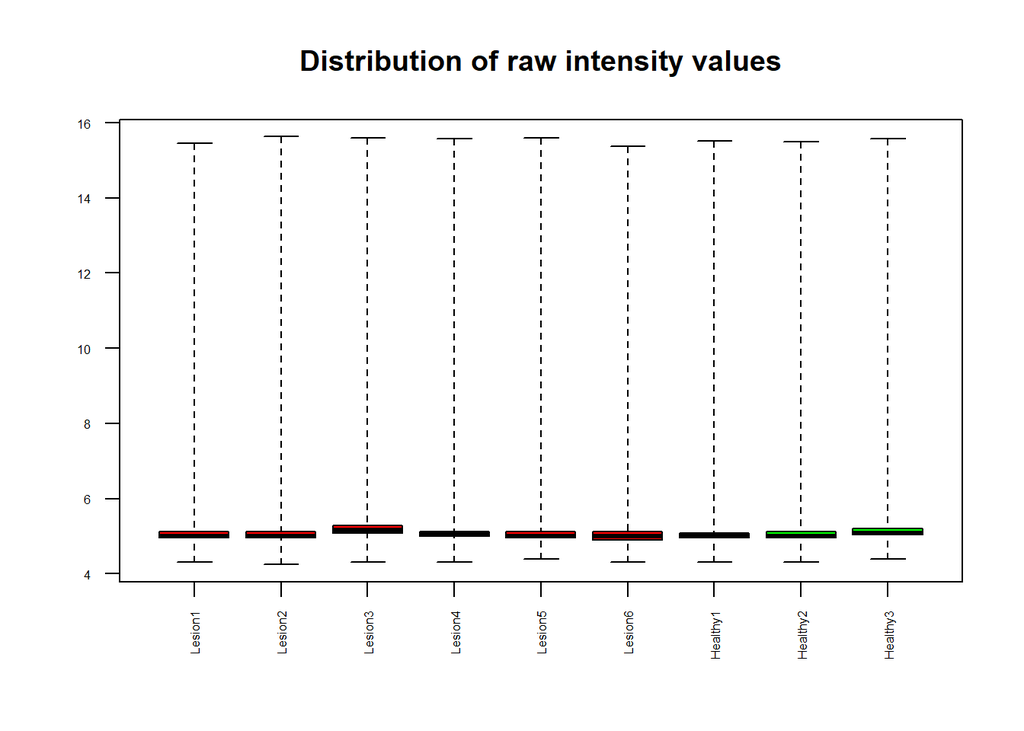

```r
boxplot(raw_data, cex.axis=0.5, las=2, which="all", col=c(rep("red", 6), rep("green", 3)), main="Distribution of raw intensity values")
```

```r
arrayQualityMetrics(raw_data, outdir = "../results_mirna/raw_data", force = TRUE)
res <- "../results_mirna/raw_data/index.html"
tables <- readHTMLTable(res)
table_QC<-tables[[1]]
knitr::kable(table_QC)
```

|  | array | sampleNames | *1 | *2 | *3 | Group | ShortName |
| --- | --- | --- | --- | --- | --- | --- | --- |
|  | 1 | Lesion1 |  |  |  | Lesion | Lesion1 |
|  | 2 | Lesion2 |  |  |  | Lesion | Lesion2 |
|  | 3 | Lesion3 | x | x | x | Lesion | Lesion3 |
|  | 4 | Lesion4 |  |  |  | Lesion | Lesion4 |
|  | 5 | Lesion5 |  |  |  | Lesion | Lesion5 |
|  | 6 | Lesion6 |  |  | x | Lesion | Lesion6 |
|  | 7 | Healthy1 |  |  |  | Healthy | Healthy1 |
|  | 8 | Healthy2 |  |  |  | Healthy | Healthy2 |
|  | 9 | Healthy3 |  |  |  | Healthy | Healthy3 |

Se puede observar cierta variabilidad entre los distintos microarrays. El control de calidad revela especialmente una muestra con una calidad preocupante, concretamente la muestra ‘Lesion3’, que es detectada como outlier a través de los tres métodos distintos (distancia entre arrays, boxplots y MA plots). Además, la muestra ‘Lesion6’ también es detectada como posible outlier mediante los MA plots. Antes de descartar las muestras, se procede a la normalización de las muestras para evaluar si se corrigen estas observaciones.

# Normalización de los datos

A continuación, se normalizan los datos para corregir la variabilidad técnica entre las distintas muestras. Se usarán tres métodos distintos para comprobar cuál de ellos arroja mejores resultados. Primero, se realizará la normalización por el método RMA, ampliamente usado en la literatura científica, aunque algunos artículos cuestionan su adecuación para normalizar arrays de miRNA (Wang and Xi (2013)). Seguidamente, se realizará una normalización por cuantiles, incluyendo detección de valores atípicos, y posterior transformación logarítmica (Mastriani, Zhai, and Zhu (2018)). Finalmente, los microarrays serán normalizados mediante el método cyclic loess (Wu et al. (2013)). Para los dos últimos métodos, primero se filtrarán solo las sondas de la especie humana, para que las intensidades de las sondas de otras especies no interfieran en el proceso de normalización.

```r
#RMA
norm_rma <- oligo::rma(raw_data)
```

```
## Background correcting
## Normalizing
## Calculating Expression
```

```r
#Quantile
summarized_rma <- oligo::rma(raw_data,
                             background=FALSE,
                             normalize=FALSE) #summarize probes
```

```
## Calculating Expression
```

```r
expr_data <- exprs(summarized_rma)

feat_data <- read.csv("C:/Users/Lidat/Desktop/Màster Bioinformàtica i Bioestadística UOC/TFM UOC/midata/miRNA4.0_annotations.csv", comment.char="#")
rownames(feat_data)<-feat_data$Probe.Set.ID

featureData(summarized_rma)@data<-feat_data[match(rownames(featureData(summarized_rma)@data),feat_data$Probe.Set.Name),]

filtered_data<-expr_data[summarized_rma@featureData@data$Species.Scientific.Name=="Homo sapiens",]
dim(filtered_data)
```

```
## [1] 6631    9
```

```r
quant_data <- normalizeBetweenArrays(filtered_data, method = "quantile") #quantile normalization

qu <- as.numeric(quantile(quant_data, c(0, 0.25, 0.5, 0.75, 0.99, 1.0), na.rm = TRUE)) #quantiles definition

filt <- (qu[5] > 100 || (qu[6] - qu[1] > 50 && qu[2] > 0) || (qu[2] > 0 && qu[2] < 1 && qu[4] > 1 && qu[4] < 2)) #filter to check atypical values

if (filt) {
    quant_data[quant_data <= 0] <- NaN
    quant_data <- log2(quant_data)
}
#apply filter before log2 transformation

rownames(samples) <- samples@data$ShortName
norm_quant <- ExpressionSet(
  assayData = quant_data,
  phenoData = samples
)

#Cyclic loess

bg_corrected <- limma::backgroundCorrect(filtered_data, method = "normexp") #background correction
```

```
## Array 1 corrected
## Array 2 corrected
## Array 3 corrected
## Array 4 corrected
## Array 5 corrected
## Array 6 corrected
## Array 7 corrected
## Array 8 corrected
## Array 9 corrected
```

```r
loess_data <- normalizeCyclicLoess(x = bg_corrected, method = "pair", iterations = 3, span = 0.7)

norm_loess <- ExpressionSet(
  assayData = loess_data,
  phenoData = samples
)
```

# Control de calidad posterior a la normalización

Se repite el análisis de calidad para observar si hay algún cambio en la identificación de outliers y se realiza un Relative Log Expression (RLE) plot para comprobar que la normalización se ha realizado satisfactoriamente.

## Normalización mediante RMA

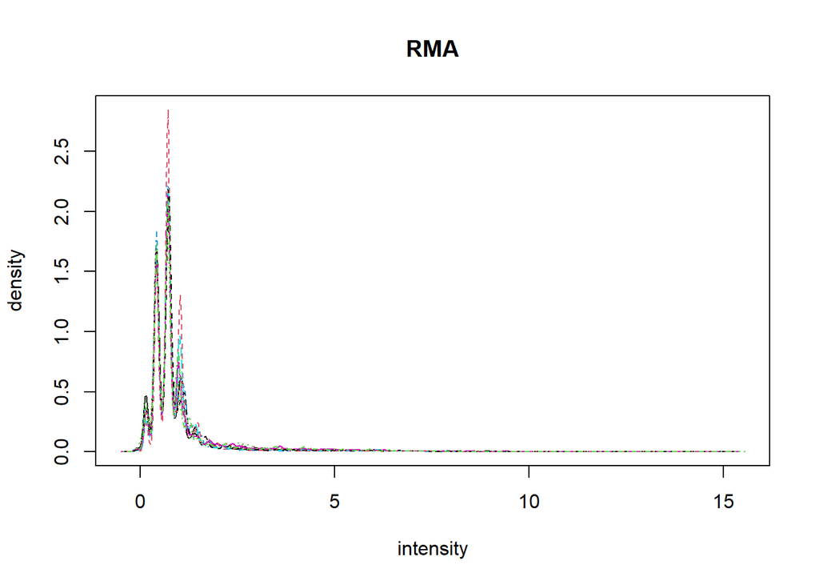

```r
hist(norm_rma, main = "RMA")
```

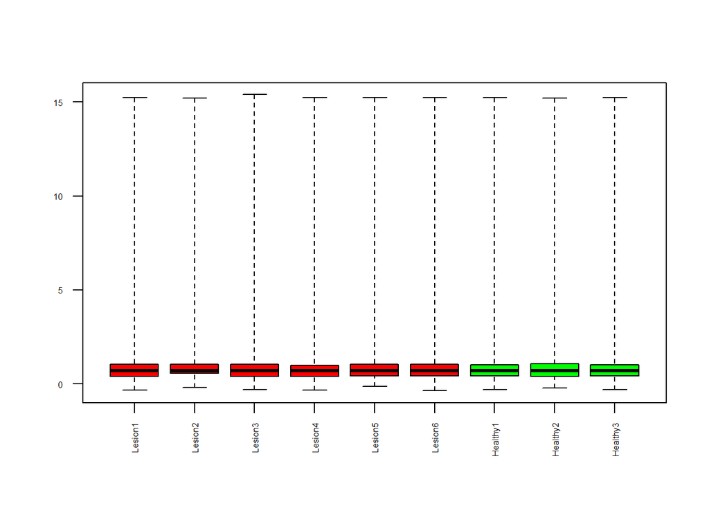

```r
boxplot(norm_rma,cex.axis=0.5, las=2,  which="all", col = c(rep("red", 6), rep("green", 3), main="Distribution of norm intensity values"))
```

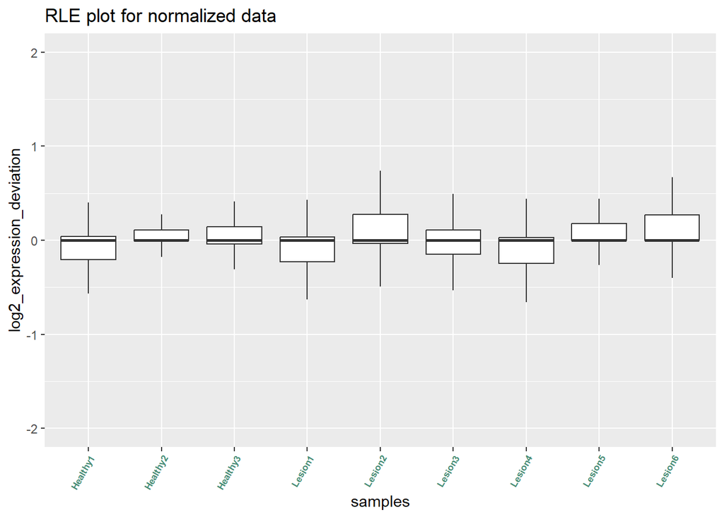

```r
expr_data_rma <- exprs(norm_rma)
RLE_plot(expr_data_rma,"RLE plot for normalized data")
```

```r
arrayQualityMetrics(norm_rma, outdir= "../results_mirna/norm_rma", force = TRUE)
res <- "../results_mirna/norm_rma/index.html"
tables <- readHTMLTable(res)
table_QC<-tables[[1]]
knitr::kable(table_QC)
```

|  | array | sampleNames | *1 | *2 | *3 | Group | ShortName |
| --- | --- | --- | --- | --- | --- | --- | --- |
|  | 1 | Lesion1 |  |  |  | Lesion | Lesion1 |
|  | 2 | Lesion2 |  | x |  | Lesion | Lesion2 |
|  | 3 | Lesion3 |  |  |  | Lesion | Lesion3 |
|  | 4 | Lesion4 |  |  |  | Lesion | Lesion4 |
|  | 5 | Lesion5 |  |  |  | Lesion | Lesion5 |
|  | 6 | Lesion6 |  |  |  | Lesion | Lesion6 |
|  | 7 | Healthy1 |  |  |  | Healthy | Healthy1 |
|  | 8 | Healthy2 |  |  |  | Healthy | Healthy2 |
|  | 9 | Healthy3 |  |  |  | Healthy | Healthy3 |

## Normalización por cuantiles

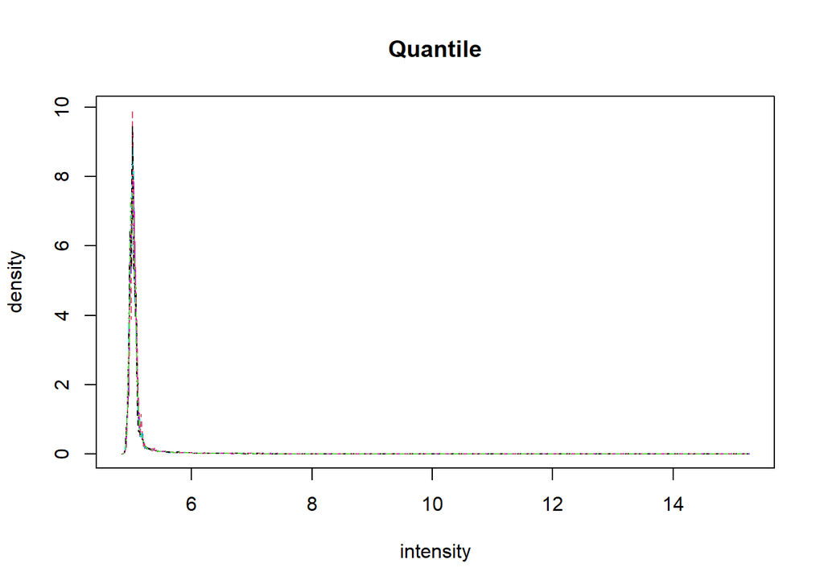

```r
hist(norm_quant, main = "Quantile")
```

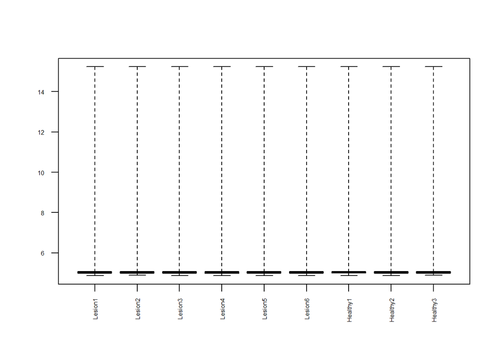

```r
boxplot(norm_quant,cex.axis=0.5, las=2,  which="all", col = c(rep("red", 6), rep("green", 3), main="Distribution of norm intensity values"))
```

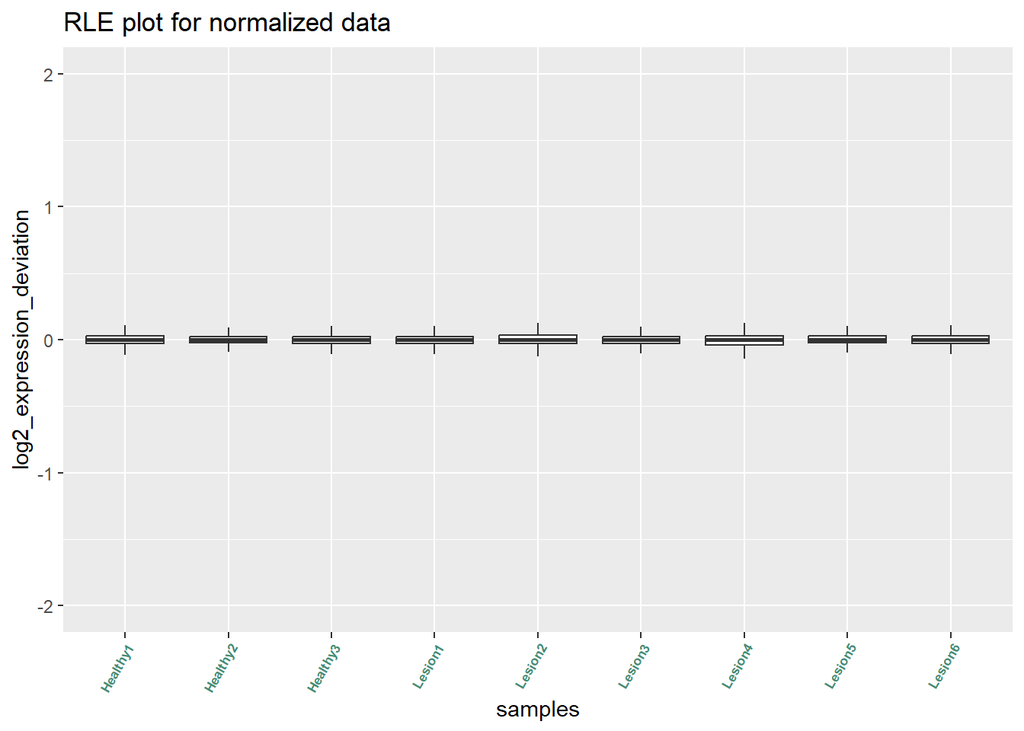

```r
expr_data_quant<- exprs(norm_quant)
RLE_plot(expr_data_quant,"RLE plot for normalized data")
```

```r
arrayQualityMetrics(norm_quant, outdir= "../results_mirna/norm_quant", force = TRUE)
res <- "../results_mirna/norm_quant/index.html"
tables <- readHTMLTable(res)
table_QC<-tables[[1]]
knitr::kable(table_QC)
```

|  | array | sampleNames | *1 | *2 | *3 | Group | ShortName |
| --- | --- | --- | --- | --- | --- | --- | --- |
|  | 1 | Lesion1 |  |  |  | Lesion | Lesion1 |
|  | 2 | Lesion2 | x |  |  | Lesion | Lesion2 |
|  | 3 | Lesion3 |  |  |  | Lesion | Lesion3 |
|  | 4 | Lesion4 | x |  |  | Lesion | Lesion4 |
|  | 5 | Lesion5 |  |  |  | Lesion | Lesion5 |
|  | 6 | Lesion6 |  |  |  | Lesion | Lesion6 |
|  | 7 | Healthy1 |  |  |  | Healthy | Healthy1 |
|  | 8 | Healthy2 |  |  |  | Healthy | Healthy2 |
|  | 9 | Healthy3 |  |  |  | Healthy | Healthy3 |

## Normalización mediante Cyclic loess

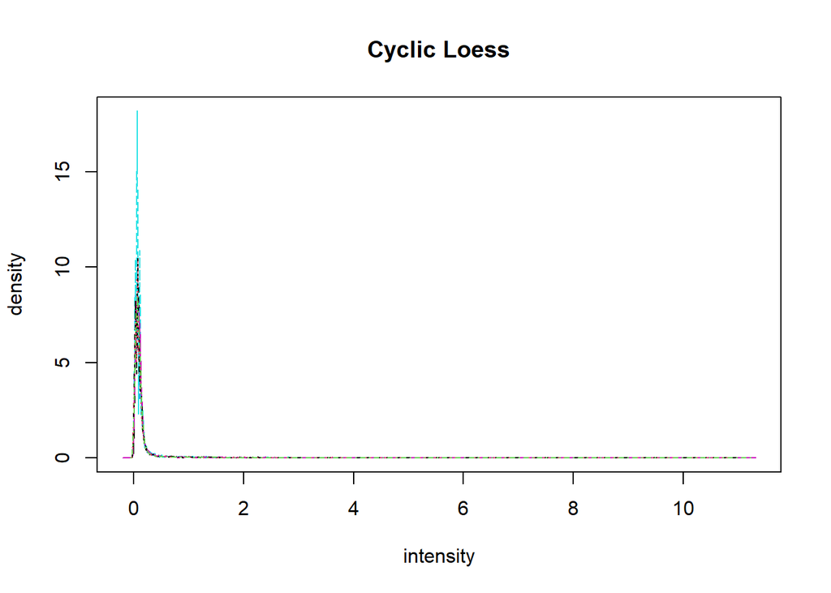

```r
hist(norm_loess, main = "Cyclic Loess")
```

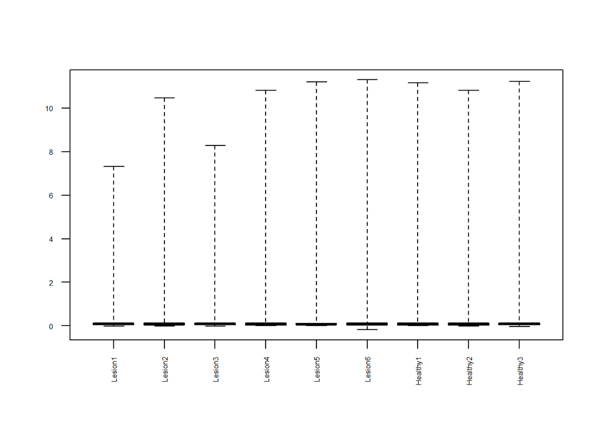

```r
boxplot(norm_loess,cex.axis=0.5, las=2,  which="all", col = c(rep("red", 6), rep("green", 3), main="Distribution of norm intensity values"))
```

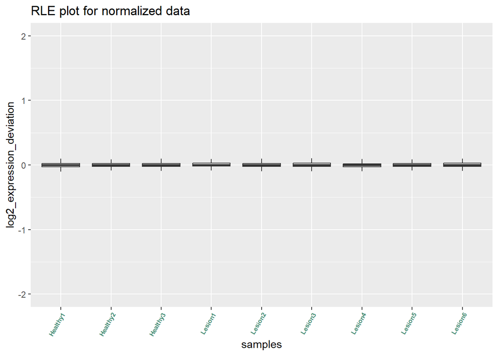

```r
expr_data_loess <- exprs(norm_loess)
RLE_plot(expr_data_loess,"RLE plot for normalized data")
```

```r
arrayQualityMetrics(norm_loess, outdir= "../results_mirna/norm_loess", force = TRUE)
res <- "../results_mirna/norm_loess/index.html"
tables <- readHTMLTable(res)
table_QC<-tables[[1]]
knitr::kable(table_QC)
```

|  | array | sampleNames | *1 | *2 | *3 | Group | ShortName |
| --- | --- | --- | --- | --- | --- | --- | --- |
|  | 1 | Lesion1 |  |  |  | Lesion | Lesion1 |
|  | 2 | Lesion2 |  |  |  | Lesion | Lesion2 |
|  | 3 | Lesion3 |  |  |  | Lesion | Lesion3 |
|  | 4 | Lesion4 |  |  |  | Lesion | Lesion4 |
|  | 5 | Lesion5 |  |  |  | Lesion | Lesion5 |
|  | 6 | Lesion6 |  |  |  | Lesion | Lesion6 |
|  | 7 | Healthy1 |  |  |  | Healthy | Healthy1 |
|  | 8 | Healthy2 |  |  |  | Healthy | Healthy2 |
|  | 9 | Healthy3 |  |  |  | Healthy | Healthy3 |

# Análisis exploratorio

Finalmente, se visualiza la agrupación de las muestras mediante un análisis de componentes principales (PCA) y un análisis de clustering según las distancias entre las muestras normalizadas por cuantiles y por cyclic loess.

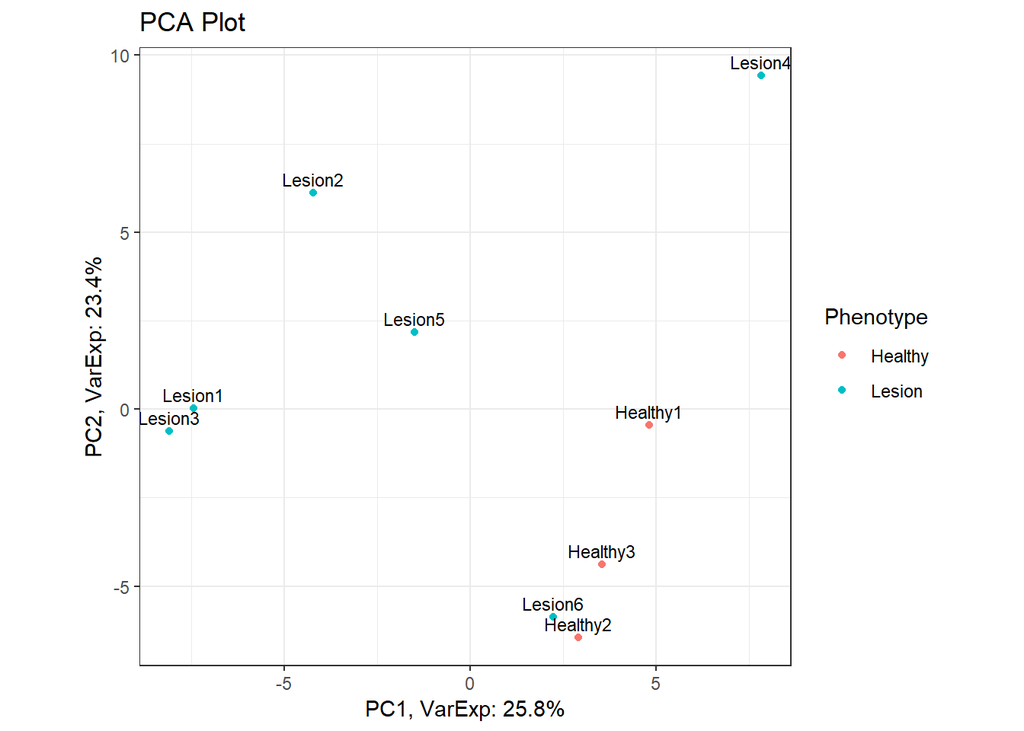

```r
groups <- pData(norm_quant)$Group
names <- pData(norm_quant)$ShortName

#PCA for quantile-normalized data

PCA_plot(expr_data_quant, groups, names)
```

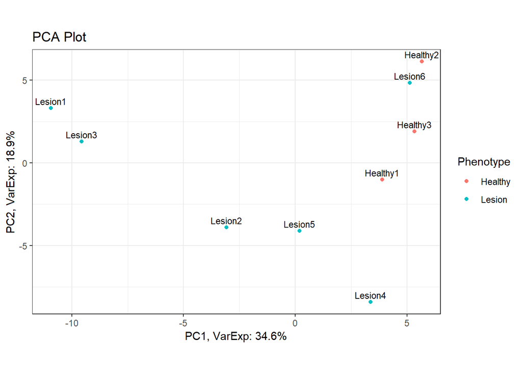

```r
#PCA for cyclic loess data

PCA_plot(expr_data_loess, groups, names)
```

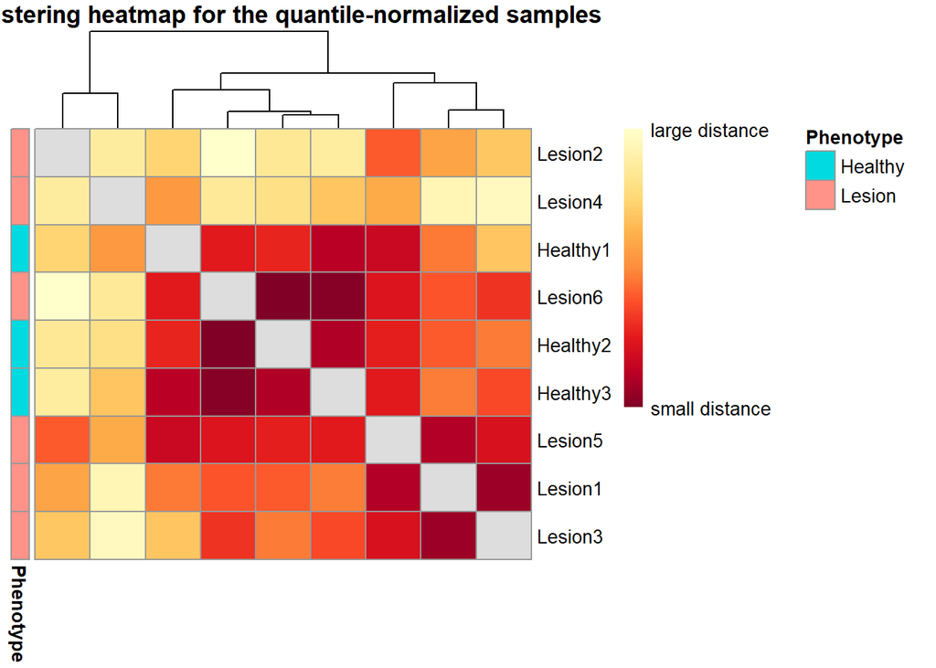

```r
#Heatmap for quantile-normalized data

annotation_for_heatmap <-
  data.frame(Phenotype = groups)

row.names(annotation_for_heatmap) <- row.names(pData(norm_quant))

dists <- as.matrix(dist(t(expr_data_quant), method = "manhattan"))

rownames(dists) <- row.names(pData(norm_quant))
hmcol <- rev(colorRampPalette(RColorBrewer::brewer.pal(9, "YlOrRd"))(255))
colnames(dists) <- NULL
diag(dists) <- NA

set.seed(123)
pheatmap(dists, col = (hmcol),
         annotation_row = annotation_for_heatmap,
         legend = TRUE,
         treeheight_row = 0,
         legend_breaks = c(min(dists, na.rm = TRUE),
                         max(dists, na.rm = TRUE)),
         legend_labels = (c("small distance", "large distance")),
         main = "Clustering heatmap for the quantile-normalized samples")
```

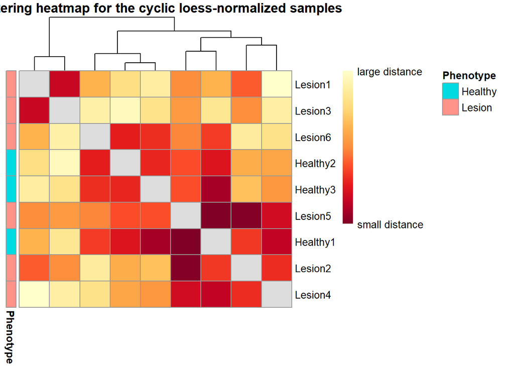

```r
#Heatmap for cyclic loess data

dists <- as.matrix(dist(t(expr_data_loess), method = "manhattan"))

hmcol <- rev(colorRampPalette(RColorBrewer::brewer.pal(9, "YlOrRd"))(255))
colnames(dists) <- NULL
diag(dists) <- NA

set.seed(123)
pheatmap(dists, col = (hmcol),
         annotation_row = annotation_for_heatmap,
         legend = TRUE,
         treeheight_row = 0,
         legend_breaks = c(min(dists, na.rm = TRUE),
                         max(dists, na.rm = TRUE)),
         legend_labels = (c("small distance", "large distance")),
         main = "Clustering heatmap for the cyclic loess-normalized samples")
```

# Referencias

Mastriani, Emilio, Rihong Zhai, and Songling Zhu. 2018. “Microarray-Based MicroRNA Expression Data Analysis with Bioconductor.” In *Methods in Molecular Biology*, 1751:127–38. Humana Press Inc. https://doi.org/10.1007/978-1-4939-7710-9_9.

Wang, Bin, and Yaguang Xi. 2013. “Challenges for MicroRNA Microarray Data Analysis.” *Microarrays* 2 (March): 34–50. https://doi.org/10.3390/microarrays2020034.

Wu, Di, Yifang Hu, Stephen Tong, Bryan R. G. Williams, Gordon K. Smyth, and Michael P. Gantier. 2013. “The Use of miRNA Microarrays for the Analysis of Cancer Samples with Global miRNA Decrease.” *RNA* 19 (July): 876–88. https://doi.org/10.1261/rna.035055.112.